# Kuo et al 2010 CgAp-1 Reanalysis

Bin He

**Goal**

Reanalyze Yap1 ChIP in *C. glabrata* in order to identify the genomic regions bound by the TF.

**Reference** 1. Kuo D, Licon K, Bandyopadhyay S, Chuang R, Luo C, Catalana J, et al. Coevolution within a transcriptional network by compensatory trans and cis mutations. Genome Res. 2010 Dec 1;20(12):1672â“8.

**Data** Three replicates for CgAp-1 ChIP. For each replicate, the IP enriched DNA is labeled with Cy5 (and the corresponding unenriched (input) DNA is labeled with Cy3. The mixture of the two was hybridized to a custom Agilent microarray, scanned using a Genepix 4000A scanner and analyzed by GenePix 6.0, producing a two-color array dataset in the gpr format.

## Setup the environment

```r
require(limma)
require(ggplot2)
require(Biobase)
require(GEOquery)
```

## Data preparation

There are three files in total, corresponding to the three replicates, with the names of GSM397447,48,49

```r
# first load the data for QC. Note that these files will not be used in latter analysis
# see doc/notes-hb.org for reasons
# load target data frame, containing the sample information and file names
targets <- readTargets("../data/yap1-chip-sample.txt",row.names = "Name")
# add relative path
targets$FileName <- paste("../data/",targets$FileName,sep="")
# load raw data
RG <- read.maimages(targets, source="genepix")
```

```
Read ../data/GSM397447.gpr.gz
Read ../data/GSM397448.gpr.gz
Read ../data/GSM397449.gpr.gz
```

```r
# background correction using normexp method
RGb <- backgroundCorrect(RG, method="normexp", offset=50)
```

```
Array 1 corrected
Array 2 corrected
Array 3 corrected
Array 1 corrected
Array 2 corrected
Array 3 corrected
```

```r
# the normexp method was recommended by LIMMA manual. within array normalization is then applied on the background corrected dataset
MA <- normalizeWithinArrays(RGb)
```

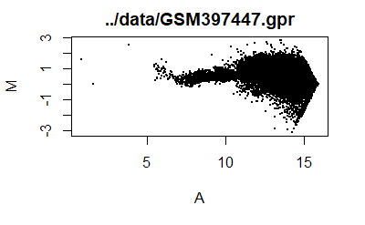

```r
# plot QC in a pdf file
# pdf(paste("../output/figure/",format(Sys.time(),"%Y-%m-%d-"),"data-qc.pdf",sep=""))
# MA plot
plotMD(RG, column=1)
```

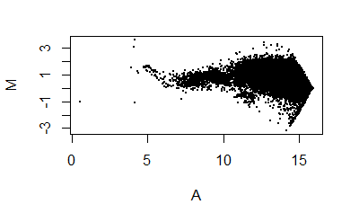

```r
plotMD(RG, column=2)
```

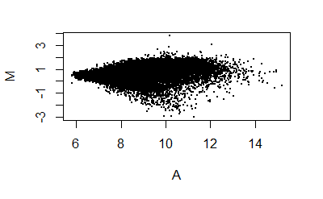

```r
plotMD(RG, column=3)
```

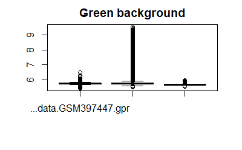

```r
# Boxplot for the background intensities
boxplot(data.frame(log2(RG$Gb)),main="Green background")
```

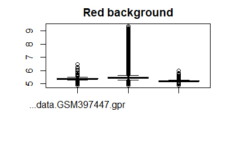

```r
boxplot(data.frame(log2(RG$Rb)),main="Red background")
```

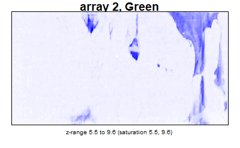

```r
# array 2 seems to have unusually high background, examine its image
imageplot(log2(RG$Gb[,2]),RG$printer, main = "array 2, Green")
```

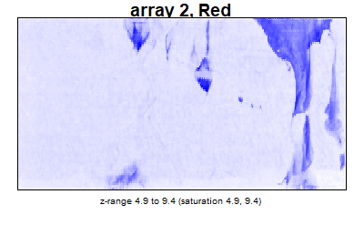

```r
imageplot(log2(RG$Rb[,2]),RG$printer, main = "array 2, Red")
```

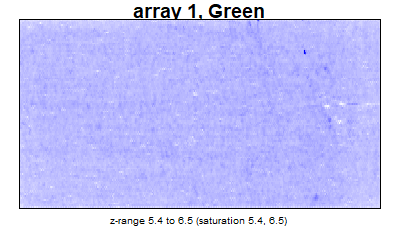

```r
# compare them to array 1 and 3
imageplot(log2(RG$Gb[,1]),RG$printer, main = "array 1, Green")
```

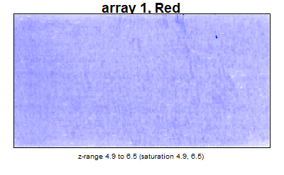

```r
imageplot(log2(RG$Rb[,1]),RG$printer, main = "array 1, Red")
```

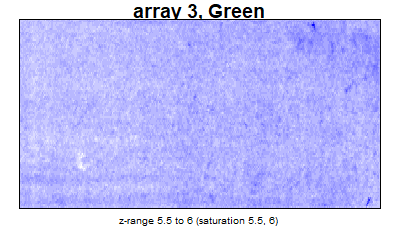

```r
imageplot(log2(RG$Gb[,3]),RG$printer, main = "array 3, Green")
```

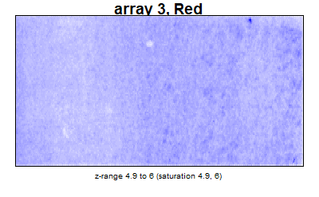

```r
imageplot(log2(RG$Rb[,3]),RG$printer, main = "array 3, Red")
```

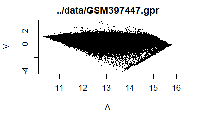

```r
# background corrected MA plots
plotMD(RGb, column=1)
```

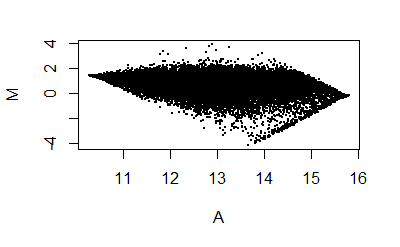

```r
plotMD(RGb, column=2)
```

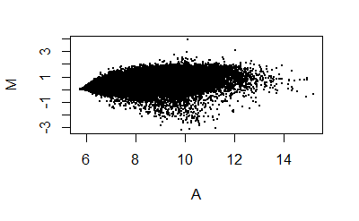

```r
plotMD(RGb, column=3)
```

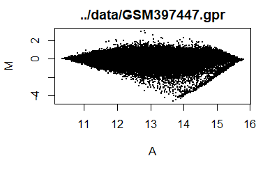

```r
# after LOESS within array normalization
plotMD(MA, column=1)
```

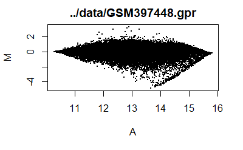

```r
plotMD(MA, column=2)
```

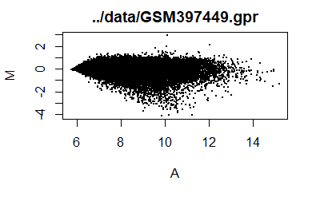

```r
plotMD(MA, column=3)
```

```r
# dev.off()
```

## Conclusion

- Still couldn’t figure out how the authors derived the normalized log10 ratios from their raw data. My test yielded largely negative outliers (meaning IP DNA is less than input)
- Learning how to parse the various formats of GEO datasets (SOFT format have a number of different formatting) is challenging. It might be easier to just extract the matrix of normalized data and use that as input for MochiView or peak finding software